# **Red Wines Exploration by Gourav Aich**

P. Cortez, A. Cerdeira, F. Almeida, T. Matos and J. Reis. Modeling wine preferences by data mining from physicochemical properties. In Decision Support Systems, Elsevier, 47(4):547-553. ISSN: 0167-9236.

Available at: [@Elsevier] http://dx.doi.org/10.1016/j.dss.2009.05.016  
[Pre-press (pdf)] http://www3.dsi.uminho.pt/pcortez/winequality09.pdf  
[bib] http://www3.dsi.uminho.pt/pcortez/dss09.bib

*This report explores a dataset containing 1599 instances of red wine and its 12 attributes. Out of these 12 attributes, eleven are based on physiochemical tests and are termed as input variables. On the other hand, the twelfth attribute “quality”, scored between 0(very bad) and 10(excellent) is based on sensory data and is termed as the output variable.*

## Univariate Plots Section

```
## [1] 1599   13
```

```
## 'data.frame':    1599 obs. of  13 variables:
##  $ X                   : int  1 2 3 4 5 6 7 8 9 10 ...
##  $ fixed.acidity       : num  7.4 7.8 7.8 11.2 7.4 7.4 7.9 7.3 7.8 7.5 ...
##  $ volatile.acidity    : num  0.7 0.88 0.76 0.28 0.7 0.66 0.6 0.65 0.58 0.5 ...
##  $ citric.acid         : num  0 0 0.04 0.56 0 0 0.06 0 0.02 0.36 ...
##  $ residual.sugar      : num  1.9 2.6 2.3 1.9 1.9 1.8 1.6 1.2 2 6.1 ...
##  $ chlorides           : num  0.076 0.098 0.092 0.075 0.076 0.075 0.069 0.065 0.073 0.071 ...
##  $ free.sulfur.dioxide : num  11 25 15 17 11 13 15 15 9 17 ...
##  $ total.sulfur.dioxide: num  34 67 54 60 34 40 59 21 18 102 ...
##  $ density             : num  0.998 0.997 0.997 0.998 0.998 ...
##  $ pH                  : num  3.51 3.2 3.26 3.16 3.51 3.51 3.3 3.39 3.36 3.35 ...
##  $ sulphates           : num  0.56 0.68 0.65 0.58 0.56 0.56 0.46 0.47 0.57 0.8 ...
##  $ alcohol             : num  9.4 9.8 9.8 9.8 9.4 9.4 9.4 10 9.5 10.5 ...
##  $ quality             : int  5 5 5 6 5 5 5 7 7 5 ...
```

```
##        X          fixed.acidity   volatile.acidity  citric.acid
##  Min.   :   1.0   Min.   : 4.60   Min.   :0.1200   Min.   :0.000
##  1st Qu.: 400.5   1st Qu.: 7.10   1st Qu.:0.3900   1st Qu.:0.090
##  Median : 800.0   Median : 7.90   Median :0.5200   Median :0.260
##  Mean   : 800.0   Mean   : 8.32   Mean   :0.5278   Mean   :0.271
##  3rd Qu.:1199.5   3rd Qu.: 9.20   3rd Qu.:0.6400   3rd Qu.:0.420
##  Max.   :1599.0   Max.   :15.90   Max.   :1.5800   Max.   :1.000
##  residual.sugar     chlorides       free.sulfur.dioxide
##  Min.   : 0.900   Min.   :0.01200   Min.   : 1.00
##  1st Qu.: 1.900   1st Qu.:0.07000   1st Qu.: 7.00
##  Median : 2.200   Median :0.07900   Median :14.00
##  Mean   : 2.539   Mean   :0.08747   Mean   :15.87
##  3rd Qu.: 2.600   3rd Qu.:0.09000   3rd Qu.:21.00
##  Max.   :15.500   Max.   :0.61100   Max.   :72.00
##  total.sulfur.dioxide    density             pH          sulphates
##  Min.   :  6.00       Min.   :0.9901   Min.   :2.740   Min.   :0.3300
##  1st Qu.: 22.00       1st Qu.:0.9956   1st Qu.:3.210   1st Qu.:0.5500
##  Median : 38.00       Median :0.9968   Median :3.310   Median :0.6200
##  Mean   : 46.47       Mean   :0.9967   Mean   :3.311   Mean   :0.6581
##  3rd Qu.: 62.00       3rd Qu.:0.9978   3rd Qu.:3.400   3rd Qu.:0.7300
##  Max.   :289.00       Max.   :1.0037   Max.   :4.010   Max.   :2.0000
##     alcohol         quality
##  Min.   : 8.40   Min.   :3.000
##  1st Qu.: 9.50   1st Qu.:5.000
##  Median :10.20   Median :6.000
##  Mean   :10.42   Mean   :5.636
##  3rd Qu.:11.10   3rd Qu.:6.000
##  Max.   :14.90   Max.   :8.000
```

Our dataset consists of thirteen variables, with 1599 observations. The first variable “X” denotes the row number, and therefore, can be ignored for further analysis. Out of the remaining 12 variables, 11 are of numeric/floating data types and are also the input variables. The twelfth variable “quality” is of integer data type and is the output variable.

Just by looking at the summary, the following variables seem to have some extreme max. values/outliers when compared to their means and 3rd Quartile values:

- residual.sugar
- chlorides
- free.sulfur.dioxide
- total.sulfur.dioxide
- sulphates

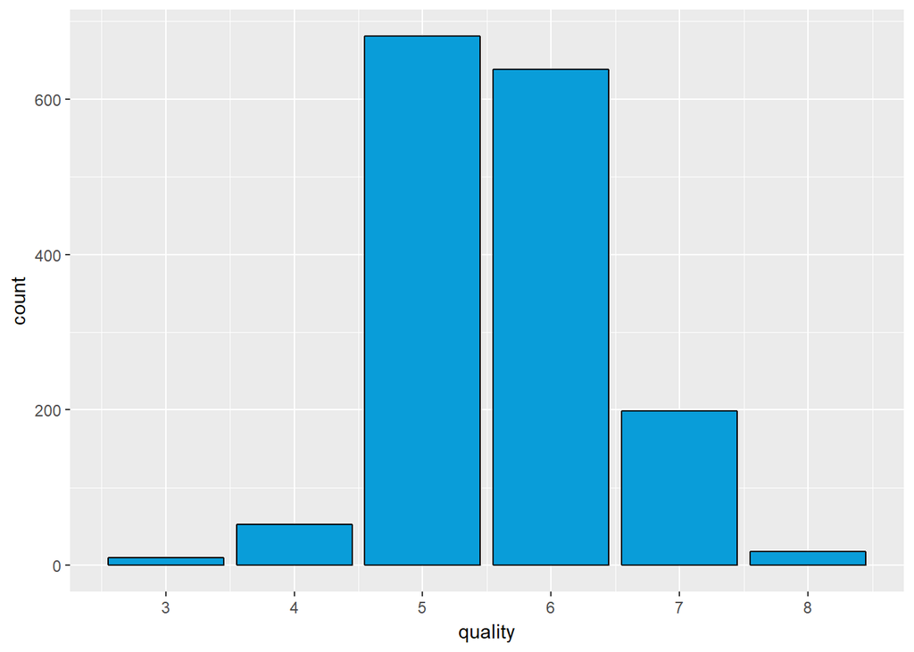

```
##
##   3   4   5   6   7   8
##  10  53 681 638 199  18
```

The **quality** histogram above has a normal distribution, peaking at quality equal to 5 and 6. It’s worth mentioning here that a lot of common statistical techniques, like linear regression (which we will use as we plan to seek correlation between quality and other variables), are based on the assumption that variables have normal distributions.

The table below the histogram shows us that more than 80% of the wine samples were graded average by experts.

Now, let’s plot histograms and boxplots for the input variables to understand their distributions and outliers respectively.

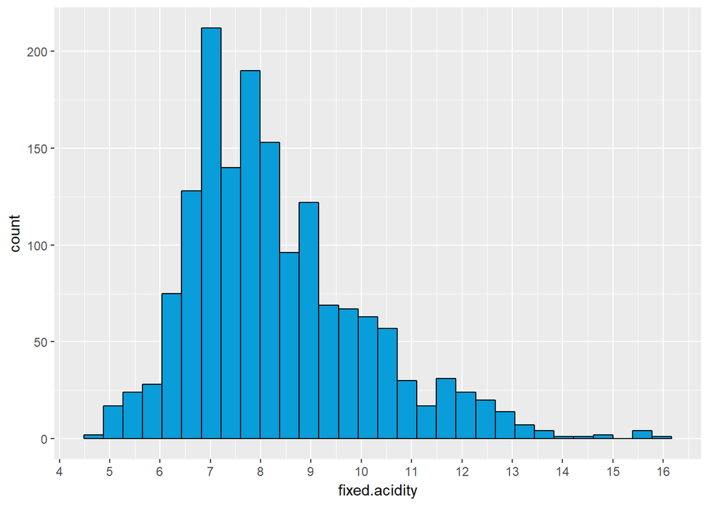

```
##    Min. 1st Qu.  Median    Mean 3rd Qu.    Max.
##    4.60    7.10    7.90    8.32    9.20   15.90
```

The distribution of **fixed.acidity** appears bimodal and peaks at 7 and 7.75 (*approx.*).

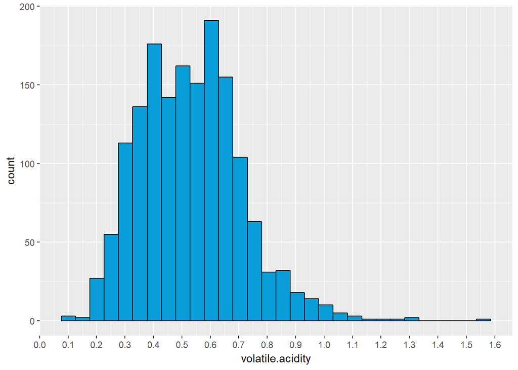

```
##    Min. 1st Qu.  Median    Mean 3rd Qu.    Max.
##  0.1200  0.3900  0.5200  0.5278  0.6400  1.5800
```

Similar to fixed.acidity, **volatile.acidity** also appears bimodal and peaks at 0.4 and 0.6.

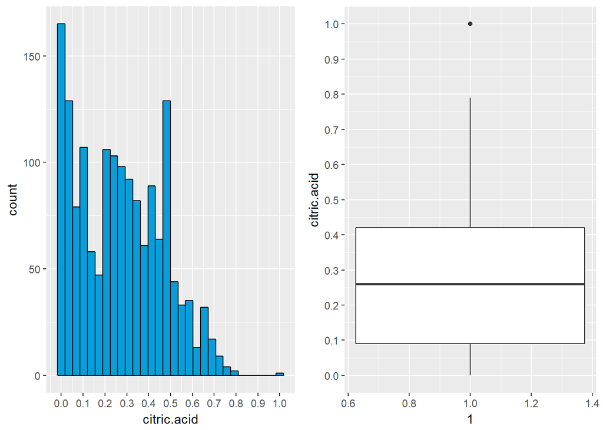

```
##    Min. 1st Qu.  Median    Mean 3rd Qu.    Max.
##   0.000   0.090   0.260   0.271   0.420   1.000
```

The histogram of **citric.acid** is positively skewed. The log transformation doesn’t help much either and just reverses the direction of skewness. However, one interesting fact to notice is the tall bar for citric.acid=0. Let’s find out the number of wines having zero citric acid.

```
## [1] 132
```

So, 132 wines are reported having no citric acid, at all. This might be an issue of non-reporting. However, a little bit of digging on the internet does reveal that many types of red wines do not contain any citric acid, according to tests conducted by the Food Standards Australia New Zealand website [http://www.livestrong.com/article/189520-what-drinks-do-not-contain-citric-acid/].  
So, I really can’t be sure about these 132 wines. Moving on, let’s take a look at the distribution of quality for wines with citric.acid=0 and otherwise.

```
## redwines$citric.acid == 0: FALSE
##
##   3   4   5   6   7   8
##   7  43 624 584 191  18
## --------------------------------------------------------
## redwines$citric.acid == 0: TRUE
##
##  3  4  5  6  7
##  3 10 57 54  8
```

The quality of red wines seems to be proportionately distributed across both the categories. However, none of the wines with citric.acid=0 are graded 8 on the quality scale.

Coming to the boxplot, it’s quite interesting to see that there is probably only 1 outlier (with citric.acid=1). Let’s extract the record(s).

```
##     X fixed.acidity volatile.acidity citric.acid residual.sugar chlorides
## 1 152           9.2             0.52           1            3.4      0.61
##   free.sulfur.dioxide total.sulfur.dioxide density   pH sulphates alcohol
## 1                  32                   69  0.9996 2.74         2     9.4
##   quality
## 1       4
```

Well, as speculated, there is only 1 wine having citric.acid=1 and it’s quality has been graded 4 (*that’s quite poor*). Does this mean that higher citric acid reduces the quality, or, being an outlier, this is probably erroneous data? It would be interesting to report our findings when I plot quality against citric.acid during our bivariate analysis.

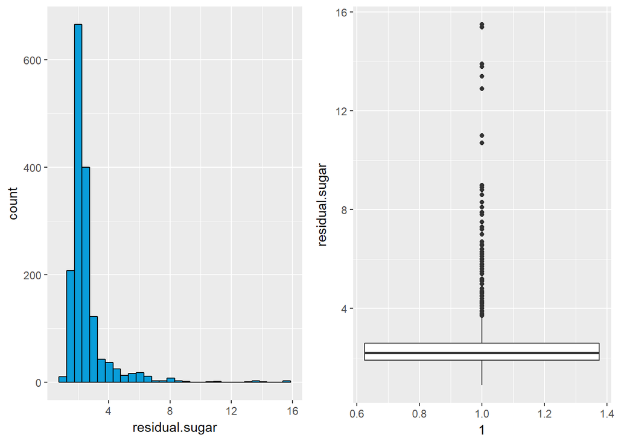

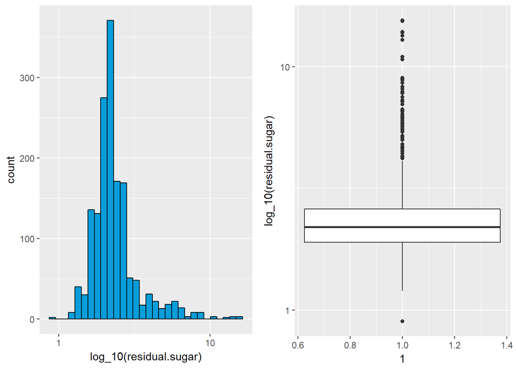

```
##    Min. 1st Qu.  Median    Mean 3rd Qu.    Max.
##   0.900   1.900   2.200   2.539   2.600  15.500
```

```
##     Min.  1st Qu.   Median     Mean  3rd Qu.     Max.
## -0.04576  0.27880  0.34240  0.36930  0.41500  1.19000
```

Transformed the long-tail data to better understand the distribution of **residual.sugar**. The log-transformed distribution is relatively less skewed and more normal. As a result of which, the second data-summary (for the log-transformed data) looks much better than the first one.

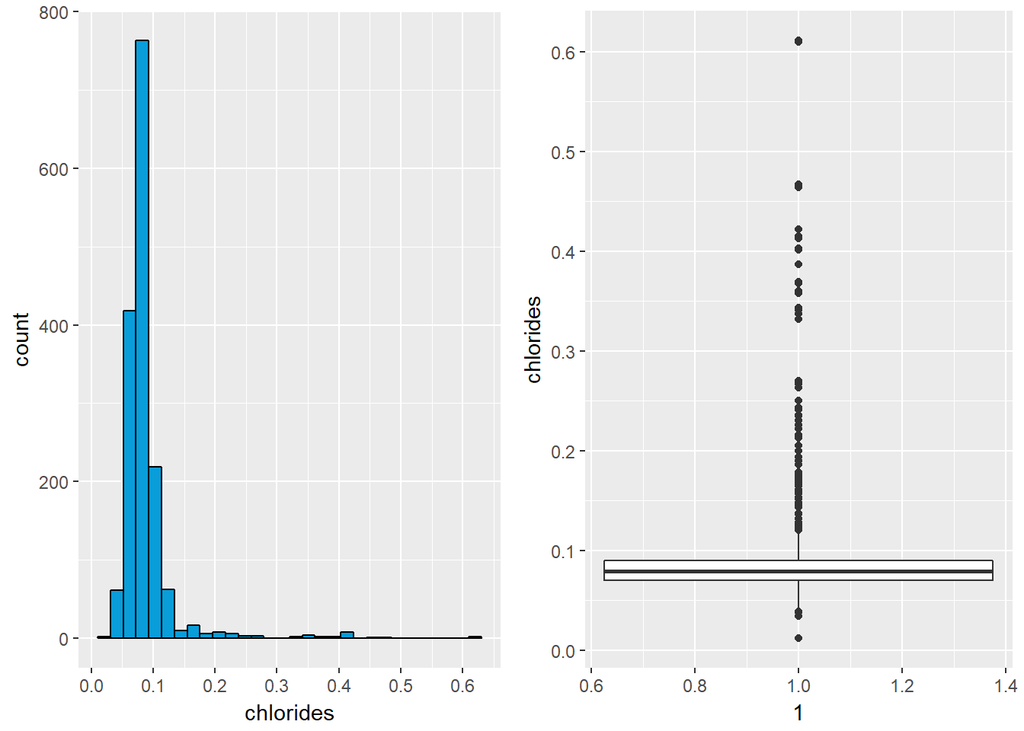

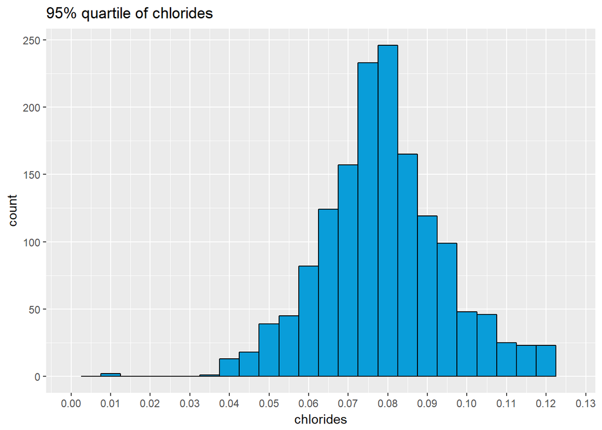

```
##    Min. 1st Qu.  Median    Mean 3rd Qu.    Max.
## 0.01200 0.07000 0.07900 0.08747 0.09000 0.61100
```

The distribution of **chlorides** is extremely right skewed. The huge difference between 3rd quartile and the max. value supports this fact as does the boxplot (*which shows several outliers*). So, I omitted the top 5% of the values (95th percentile truncated) and adjusted the binwidth. Now, the distribution appears normal. However, I can see a tiny bar at 0.01. Let’s find out these wines having chlorides < 0.02.

```
##     X fixed.acidity volatile.acidity citric.acid residual.sugar chlorides
## 1 837           6.7             0.28        0.28            2.4     0.012
## 2 838           6.7             0.28        0.28            2.4     0.012
##   free.sulfur.dioxide total.sulfur.dioxide density   pH sulphates alcohol
## 1                  36                  100 0.99064 3.26      0.39    11.7
## 2                  36                  100 0.99064 3.26      0.39    11.7
##   quality
## 1       7
## 2       7
```

Well, I have two wine samples with identical data. Do I have more such records? As I took a closer look at the dataset, I found that there are many such groups of wine samples with exactly the same data for all the columns. This is probably due to the same wine variant being graded the same by the experts.

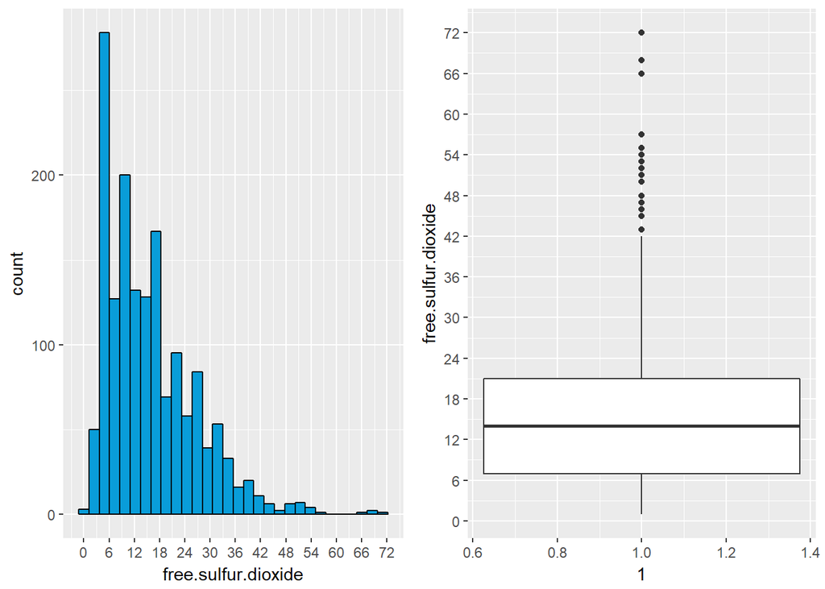

```
##    Min. 1st Qu.  Median    Mean 3rd Qu.    Max.
##    1.00    7.00   14.00   15.87   21.00   72.00
```

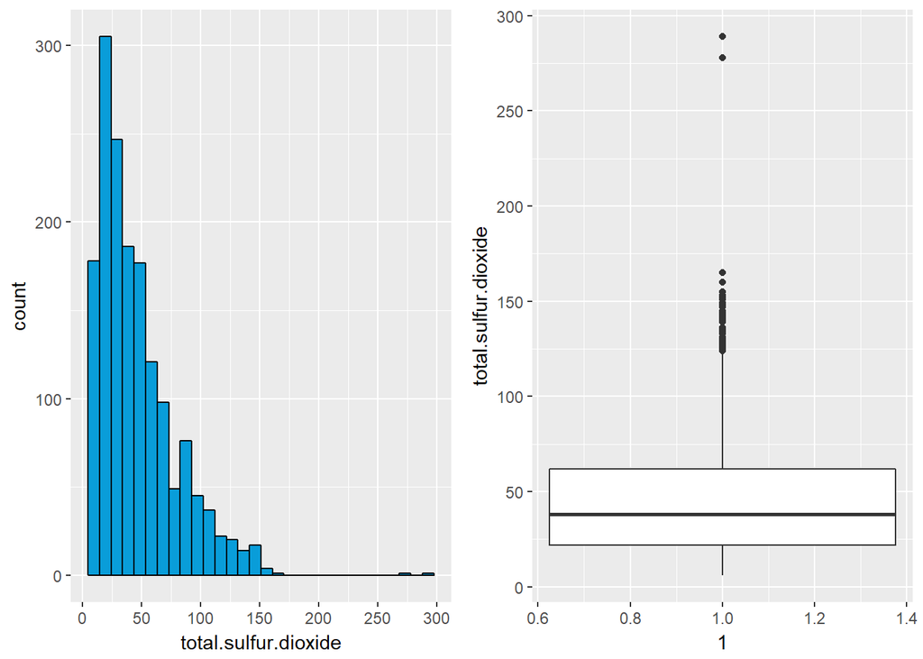

```
##    Min. 1st Qu.  Median    Mean 3rd Qu.    Max.
##    6.00   22.00   38.00   46.47   62.00  289.00
```

Similar to the previous plot, **total.sulfur.dioxide** distribution is right-skewed, too. Rather than studying these 2 related sulfur.dioxide features separately, I think it would be a good idea to combine them both.

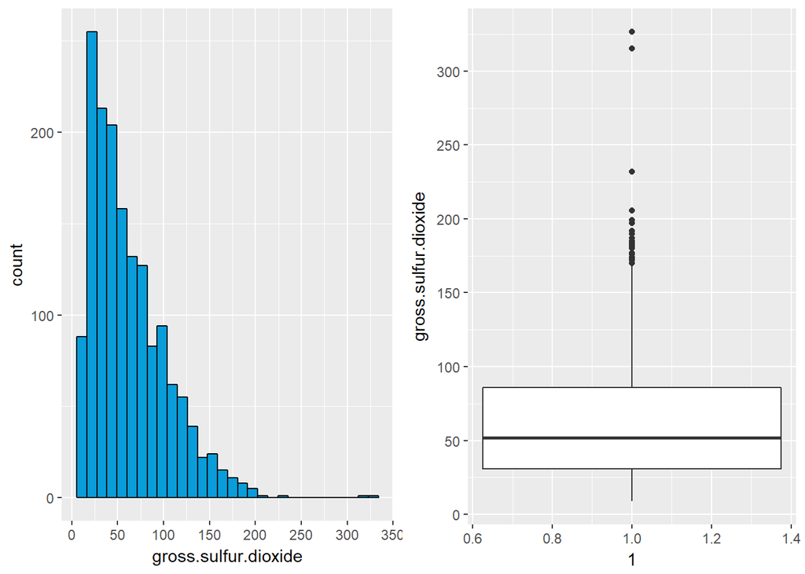

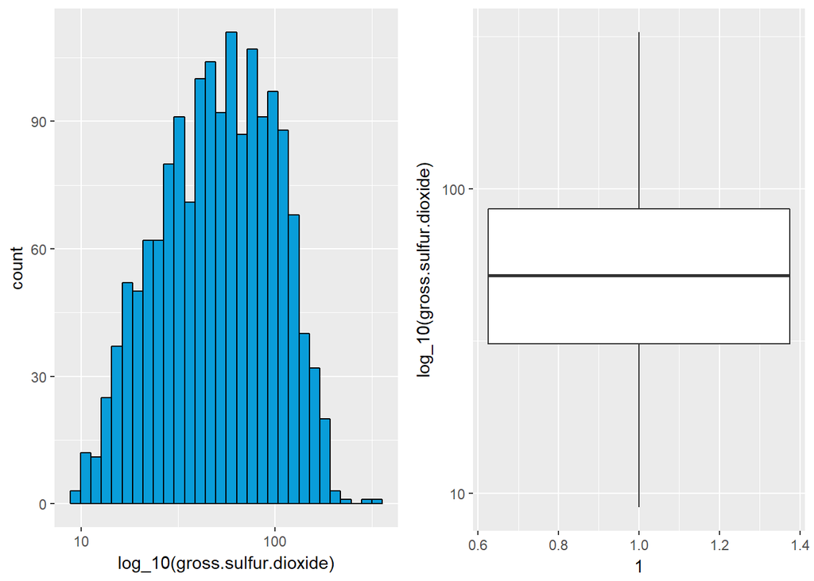

```
##    Min. 1st Qu.  Median    Mean 3rd Qu.    Max.
##    9.00   31.00   52.00   62.34   86.00  326.50
```

```
##    Min. 1st Qu.  Median    Mean 3rd Qu.    Max.
##  0.9542  1.4910  1.7160  1.7020  1.9340  2.5140
```

I summed up both the sulfur dioxides to create a new variable gross.sulfur.dioxide.  
The right skewed **gross.sulfur.dioxide** distribution is log transformed and results in a somewhat normal distribution (check both the data summaries above, the 2nd one being the log-transformed one). One interesting observation is that the boxplot of log-transformed data shows zero outliers.

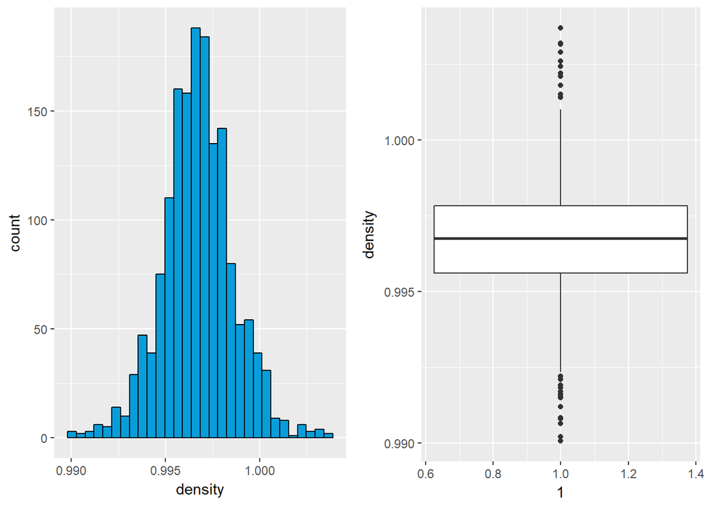

```
##    Min. 1st Qu.  Median    Mean 3rd Qu.    Max.
##  0.9901  0.9956  0.9968  0.9967  0.9978  1.0040
```

The histogram of **density** is normal with outliers appearing on both sides of the boxplot. One fact worth mentioning is that density depends on alcohol percentage and sugar content. So, it would be worth investigating their relation during further analysis.

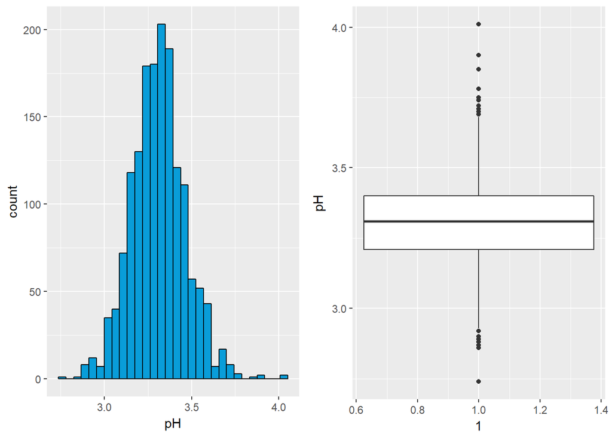

```
##    Min. 1st Qu.  Median    Mean 3rd Qu.    Max.
##   2.740   3.210   3.310   3.311   3.400   4.010
```

Similar to density, **pH**, too, has a normal distribution with outliers at both ends. pH, being a measure of acidity, might have a correlation with fixed.acidity and is definitely worth investigating.

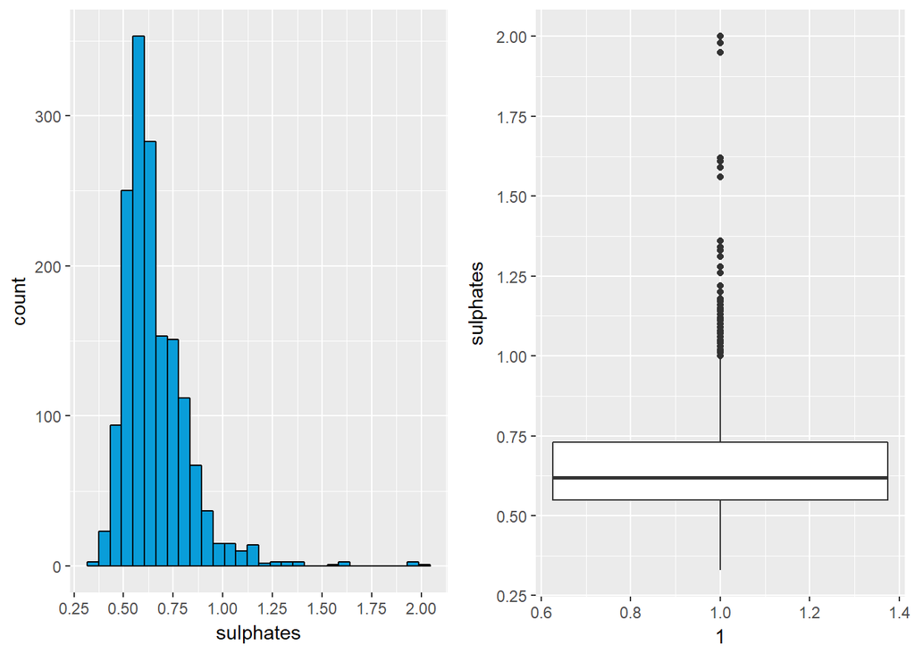

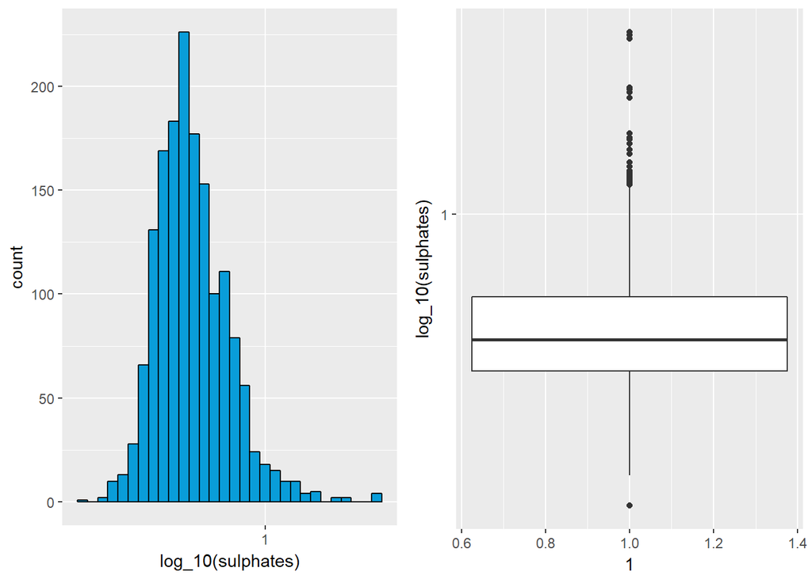

```
##    Min. 1st Qu.  Median    Mean 3rd Qu.    Max.
##  0.3300  0.5500  0.6200  0.6581  0.7300  2.0000
```

The histogram of **sulphates** is definitely long-tailed, whereas, the log-transformed data gives us a relatively normal distribution. The outliers though, still exist in large numbers.

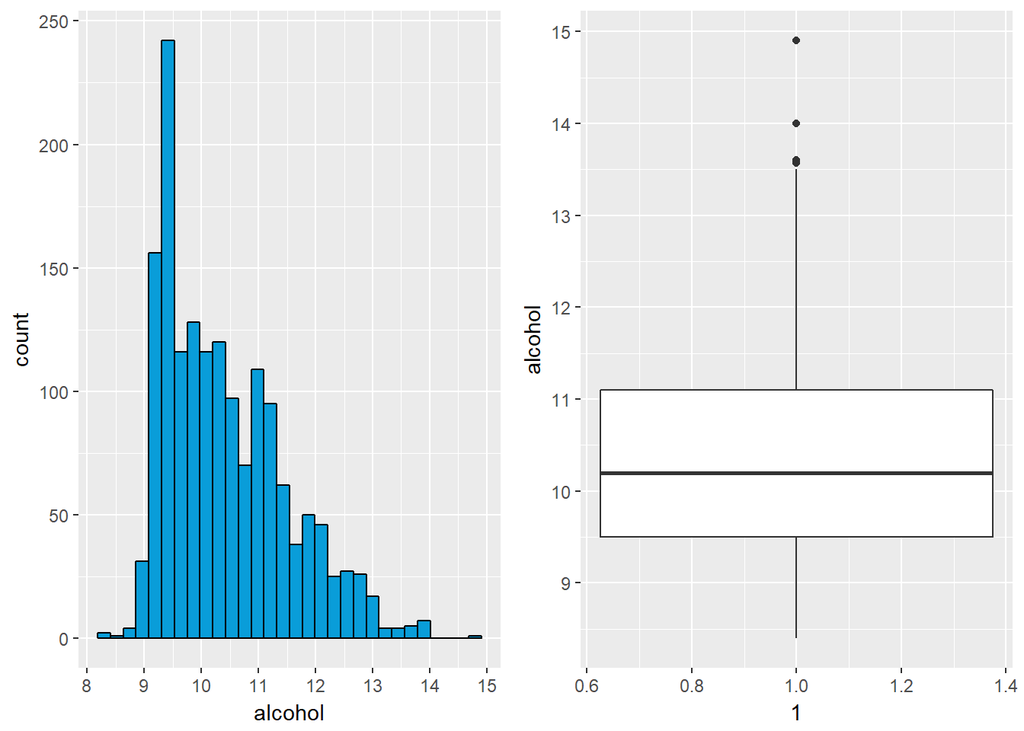

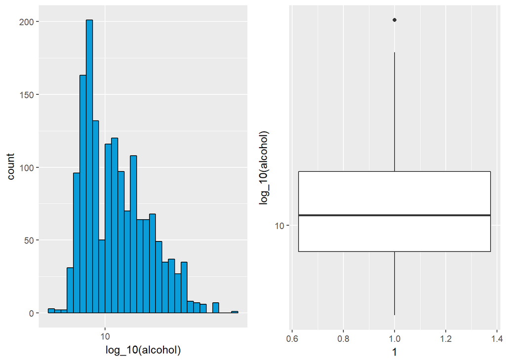

```
##    Min. 1st Qu.  Median    Mean 3rd Qu.    Max.
##    8.40    9.50   10.20   10.42   11.10   14.90
```

```
percent of wines containing less than 12% alcohol -->  [1] 89.86867
```

**Alcohol** is long-tailed with a very few outliers. Almost 90% of the wines have less than 12% alcohol. The log-transformed distribution, though resembles the actual one, reduces the outliers to just one.

## Univariate Analysis

### What is the structure of your dataset?

This dataset contains 1599 instances of red wine and its 12 attributes. Out of these 12 attributes, 11 are based on physiochemical tests and are termed as input variables. On the other hand, the twelfth attribute “quality”, scored between 0(very bad) and 10(excellent) is based on sensory data and is termed as the output variable.

Some primary observations:

- More than 80% of the wine samples are graded average (i.e. rated 5 or 6).
- 132 wines are reported having no citric acid, at all.
- Only 1 wine is reported to have a maximum value of citric acid (i.e. 1), and graded 4 on quality (poor). This happens to be the only outlier, too.
- Many wine samples in our dataset have attribute values identical to 1 or more samples.
- No outliers are found in the log-transformed distribution of total.sulfur.dioxide.
- Almost 90% of the wines have less than 12% alcohol.

### What is/are the main feature(s) of interest in your dataset?

The main feature of interest is definitely *quality*. I’d like to find out which attributes most likely affect the quality of red wine.

### What other features in the dataset do you think will help support your investigation into your feature(s) of interest?

Based on my research, these are the features that seem to contribute to the quality of a red wine:

1. *fixed.acidity* - *imparts the sourness or tartness that is a fundamental feature in wine taste*
2. *residual.sugar* - *often indicates the level of dryness (an important feature in wine taste)*
3. *alcohol* - *higher alcohols, though, can have an aromatic effect, does not have many sensory effects in wines* (we’ll find out)
4. *citric.acid* - *can add ‘freshness’ and flavor to wines*
5. *chlorides* - *gives the wine its salty taste; higher concentration is undesirable, though*
6. *gross.sulfur.dioxide* - *(sum of free and total SO<sub>2</sub>) at free sulfur dioxide (SO<sub>2</sub>) concentrations over 50 ppm, SO<sub>2</sub> becomes evident in the nose and taste of wine*

Another relevant feature of my research has been the relationship of sweetness (*imparted due to residual.sugar*) with acidity and alcohol content. It seems sweetness and acidity have an inverse relationship. Whereas, sweetness has a direct relationship with the potential alcohol in the wine.

### Did you create any new variables from existing variables in the dataset?

I created gross.sulfur.dioxide by summing up free.sulfur.dioxide and total.sulfur.dioxide.

### Of the features you investigated, were there any unusual distributions? Did you perform any operations on the data to tidy, adjust, or change the form of the data? If so, why did you do this?

I log-transformed the right-skewed **residual.sugar**, **gross.sulfur.dioxide** and **sulphates** distributions. The transformed distributions are less skewed and appear somewhat normal.

The distribution of **chlorides** being extremely right-skewed and its boxplot revealing several outliers, I omitted the top 5% of its values (95th percentile truncated) and adjusted the binwidth. The transformed distribution appears normal.

## Bivariate Plots Section

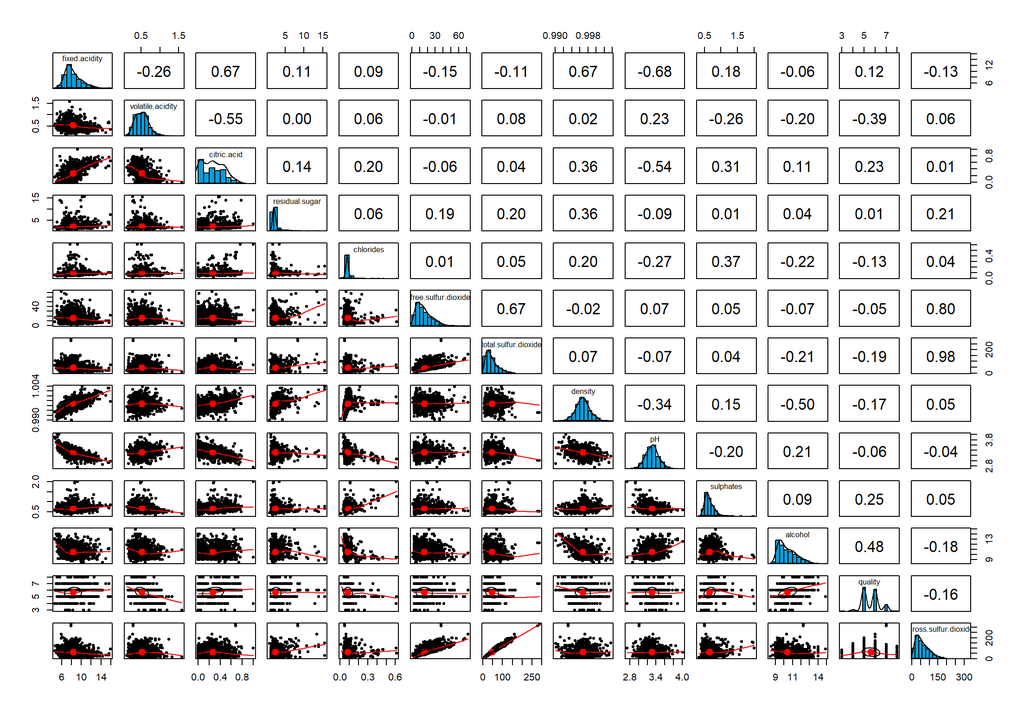

From the above scatterplot matrix, I can see that quality has a moderate positive correlation with alcohol (0.48) and a moderate negative correlation with volatile.acidity (-0.39). Surprisingly, the above matrix shows no considerable correlation between quality and fixed.acidity (0.12). A slightly higher correlation than this is reported by citric.acid (0.23) and surprisingly, sulphates (0.25). Let’s not forget that I have log-transformed the sulphates distribution and that’s what I need to plot against quality.

Coming to sulfur dioxides, quality has a better correlation value with total.sulfur.dioxide (-0.19) compared to my newly created variable, gross.sulfur.dioxide (-0.16). Contrary to what I have assumed, there is hardly any correlation between quality and residual.sugar (0.01). Similar is the case with chlorides (-0.13) but the -ve sign shows that it has an inverse relationship with quality. This, in a way, supports our assumption that higher concentration of chlorides (i.e. saltiness) is undesirable. As chlorides, too, is transformed (95th percentile truncated), I want to look closer at scatter plots involving quality and the transformed chlorides data.

The other matters of interest are the significant correlation values of density with fixed.acidity (0.67) and alcohol (-0.50). Also, interestingly, pH is positively correlated with volatile.acidity. Whereas, it is inversely related to other types of acids, such as fixed and citric (*as it should be*).

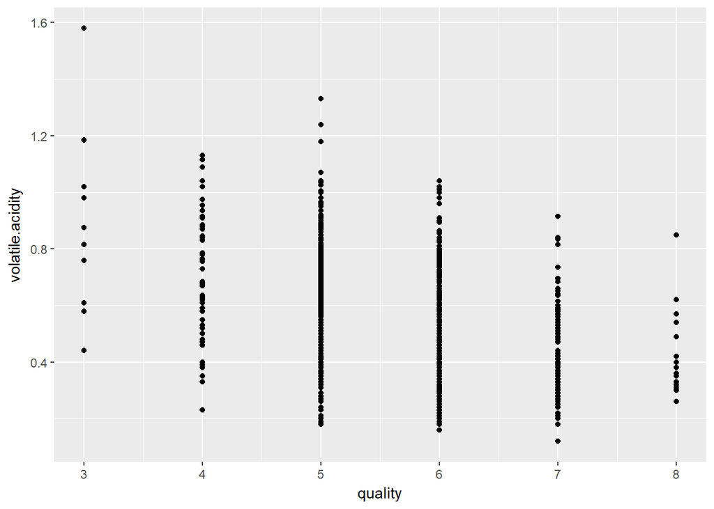

The basic scatterplot between quality and volatile.acidity isn’t as dispersed as I want it to be. Let’s add some jitter and set the transparency level at alpha=1/3.

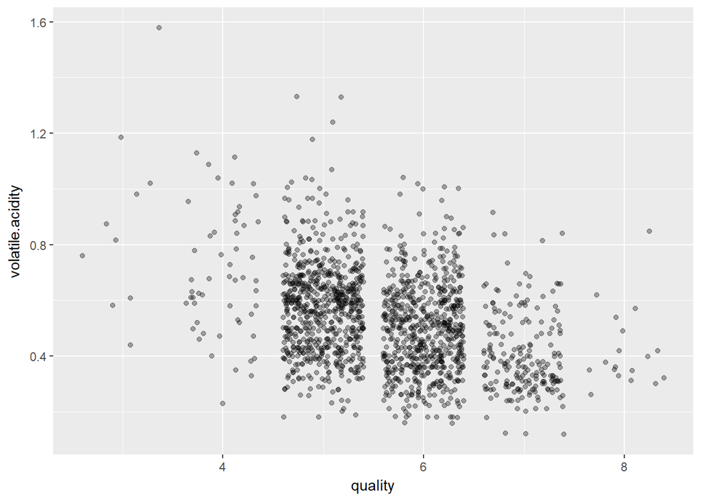

Now that I have my scatter plot, I want to overlay the summary of mean and median values of volatile.acidity.

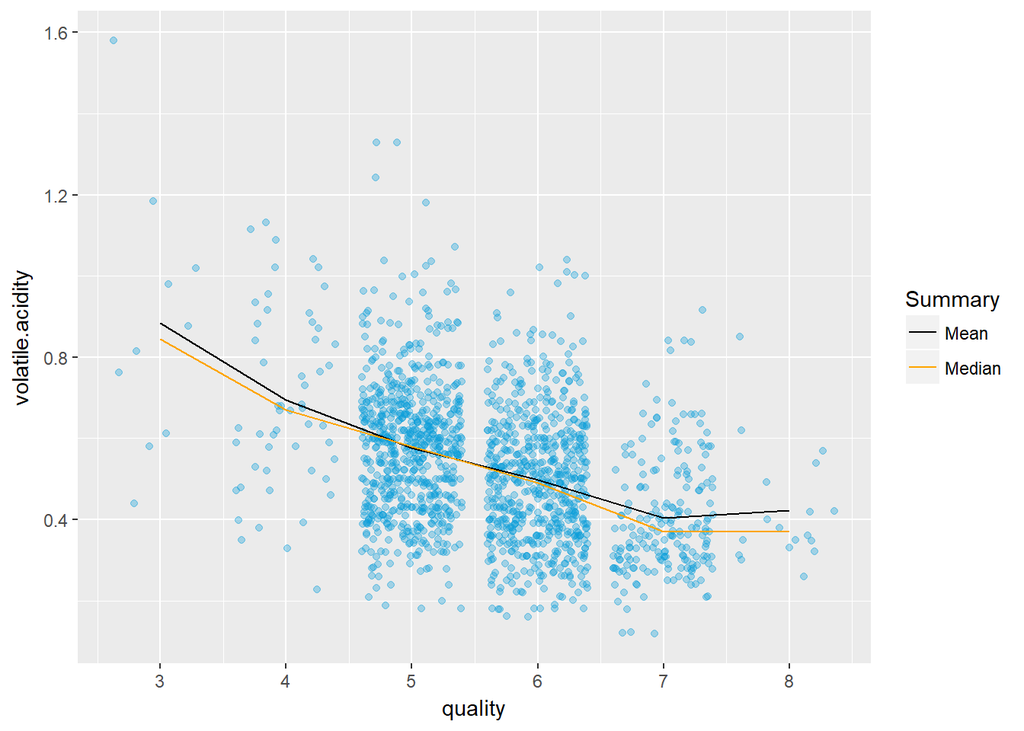

The above scatter plot reveals the decrease in volatile.acidity for wines with higher quality and a slight increase in mean volatile.acidity right after quality=7. However, the median volatile.acidity remains constant for the highest quality wines of my dataset.

Looking at mean and median summaries, I can see that the best quality wines have a volatile.acidity around 0.4.

In order to take a closer look at the count of wines and how the average volatile.acidity exactly vary over quality, I have come up with the following table for each wine quality.

```
## # A tibble: 6 × 4
##   quality   va_mean va_median     n
##     <int>     <dbl>     <dbl> <int>
## 1       3 0.8845000     0.845    10
## 2       4 0.6939623     0.670    53
## 3       5 0.5770411     0.580   681
## 4       6 0.4974843     0.490   638
## 5       7 0.4039196     0.370   199
## 6       8 0.4233333     0.370    18
```

The mean volatile.acidity keeps on decreasing with increasing quality and the wines with a mean range of volatile.acidity between 0.4 - 0.42 are graded the best on quality scale. However, the best quality wines (7 and 8) have a median volatile.acidity of 0.37.

Let’s now take a look at the other acidity features (fixed.acidity and citric.acid). I will start with the scatterplots between quality and these 2 features.

I will add some jitter to the fixed.acidity plot and set the transparency level at alpha=1/3.

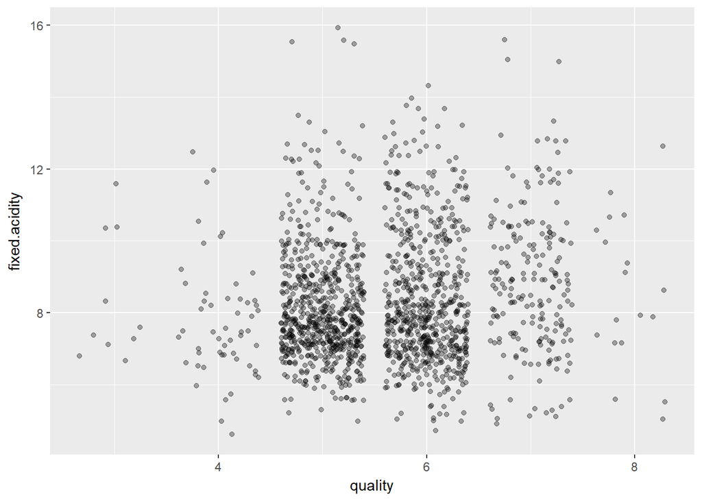

So, wines having a fixed.acidity more than 12 are mostly graded between 4 and 7. On the other hand, almost all the highest-graded wines have a fixed.acidity less than 11.

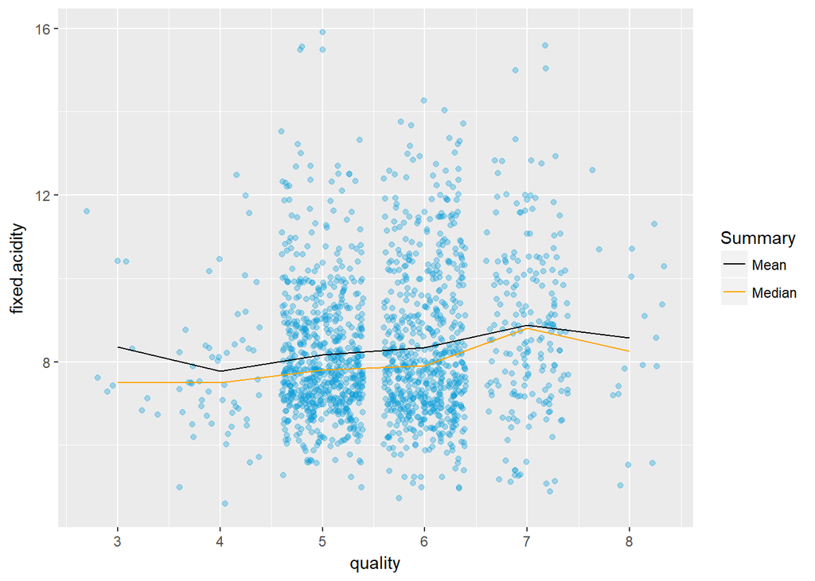

```
## # A tibble: 6 × 4
##   quality  fa_mean fa_median     n
##     <int>    <dbl>     <dbl> <int>
## 1       3 8.360000      7.50    10
## 2       4 7.779245      7.50    53
## 3       5 8.167254      7.80   681
## 4       6 8.347179      7.90   638
## 5       7 8.872362      8.80   199
## 6       8 8.566667      8.25    18
```

There isn’t really much of a correlation between fixed.acidity and quality. However, a fixed.acidity slightly greater than 8 seems to be essential for a good quality wine.

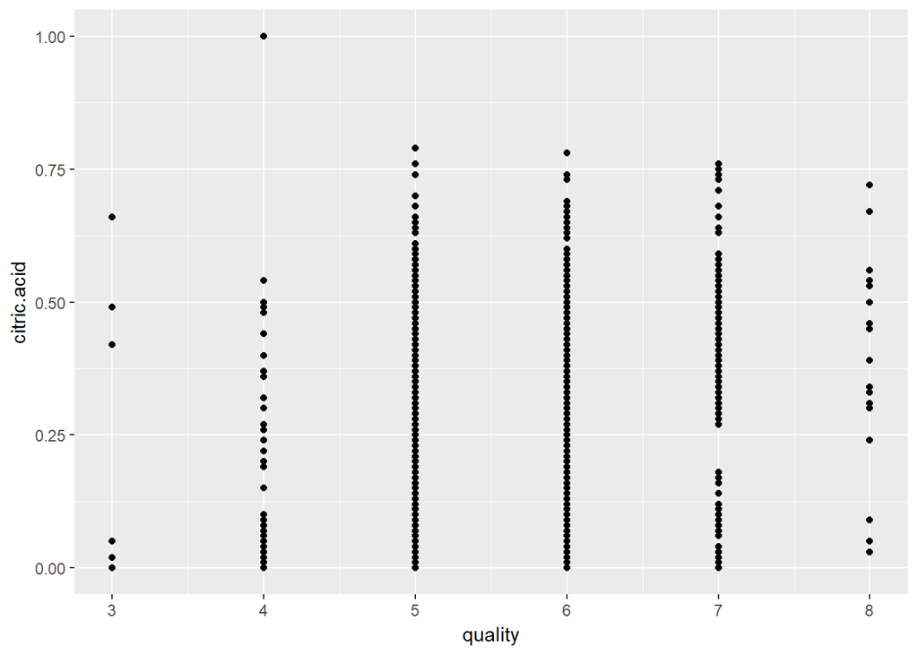

The basic scatterplot between quality and citric.acid isn’t as dispersed as we want it to be. One interesting point is that though there are many wines in our dataset that do not contain any citric.acid, none of them is graded 8 (highest) on quality.  
I will now add some jitter to fix overplotting and set the transparency level at alpha=1/3. I will also fit a linear model to check the linear relationship between citric.acid and quality.

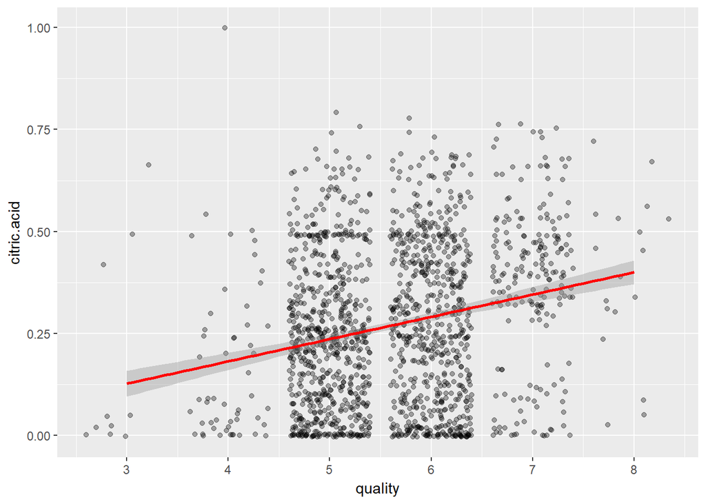

So, citric.acid and quality has a weak linear relationship where citric.acid increases with quality. I will analyse it further by overlaying the summary of mean and median values of citric.acid.

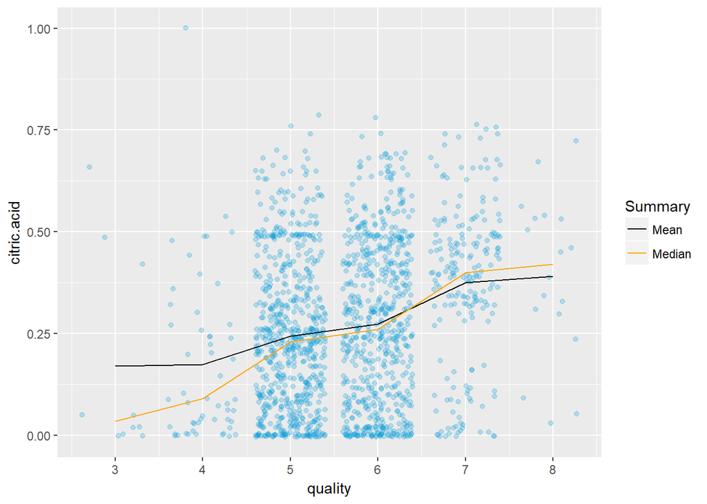

```
##
##  Pearson's product-moment correlation
##
## data:  quality and citric.acid
## t = 9.2875, df = 1597, p-value < 2.2e-16
## alternative hypothesis: true correlation is not equal to 0
## 95 percent confidence interval:
##  0.1793415 0.2723711
## sample estimates:
##       cor
## 0.2263725
```

A positive correlation of 0.22 between citric.acid and quality and the mean and median summaries peaking at the highest value of quality shows that citric.acid can improve the wine’s quality. This makes sense as citric.acid is known to add freshness and flavor to wines.  
I would now like to take a closer look at the exact mean and median values for different quality wines.

```
## # A tibble: 6 × 4
##   quality   ca_mean ca_median     n
##     <int>     <dbl>     <dbl> <int>
## 1       3 0.1710000     0.035    10
## 2       4 0.1741509     0.090    53
## 3       5 0.2436858     0.230   681
## 4       6 0.2738245     0.260   638
## 5       7 0.3751759     0.400   199
## 6       8 0.3911111     0.420    18
```

The above table supports the positive direct relationship between citric.acid and quality. A citric.acid content of 0.4 g/dm<sup>3</sup> seems to be ideal for a higher quality wine.

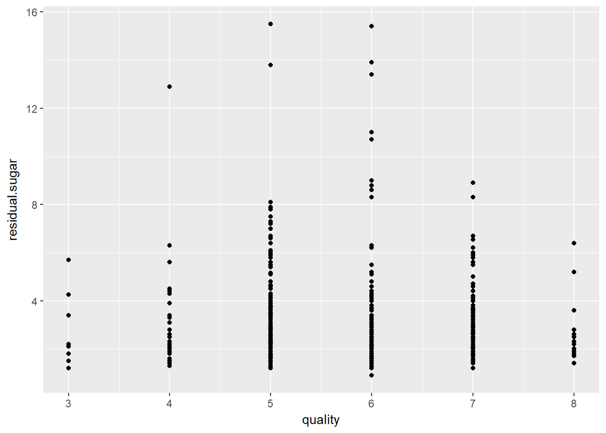

The basic scatterplot between residual.sugar and quality reveals that majority of the wines graded 6 to 8 have residual.sugar less than 7. To get a better understanding of their relationship, I will plot it again with some jitter and set the transparency level at alpha=1/4.

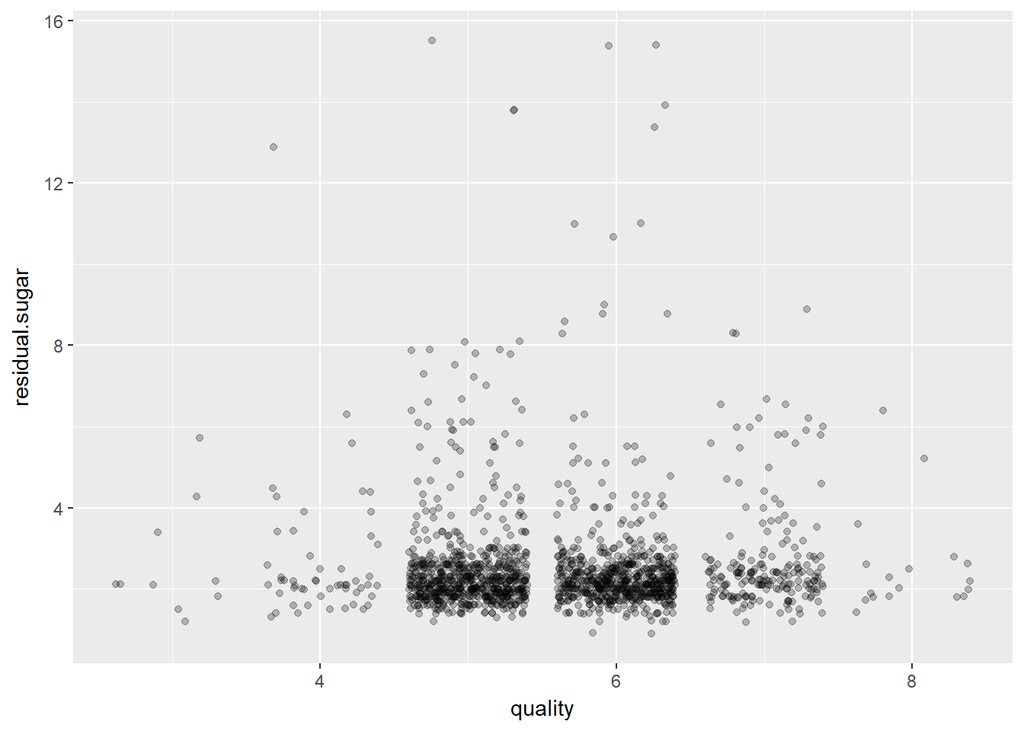

The circles are heavily concentrated towards the base of the plot and the darker ones are hovering around residual.sugar = 2. In fact, anything above the value of 8 for residual.sugar seems to be mostly outliers. There seems to be hardly any correlation between the variables.  
But, let’s not forget that residual.sugar imparts a certain sweetness to red wine which we had earlier assumed to impact its quality.

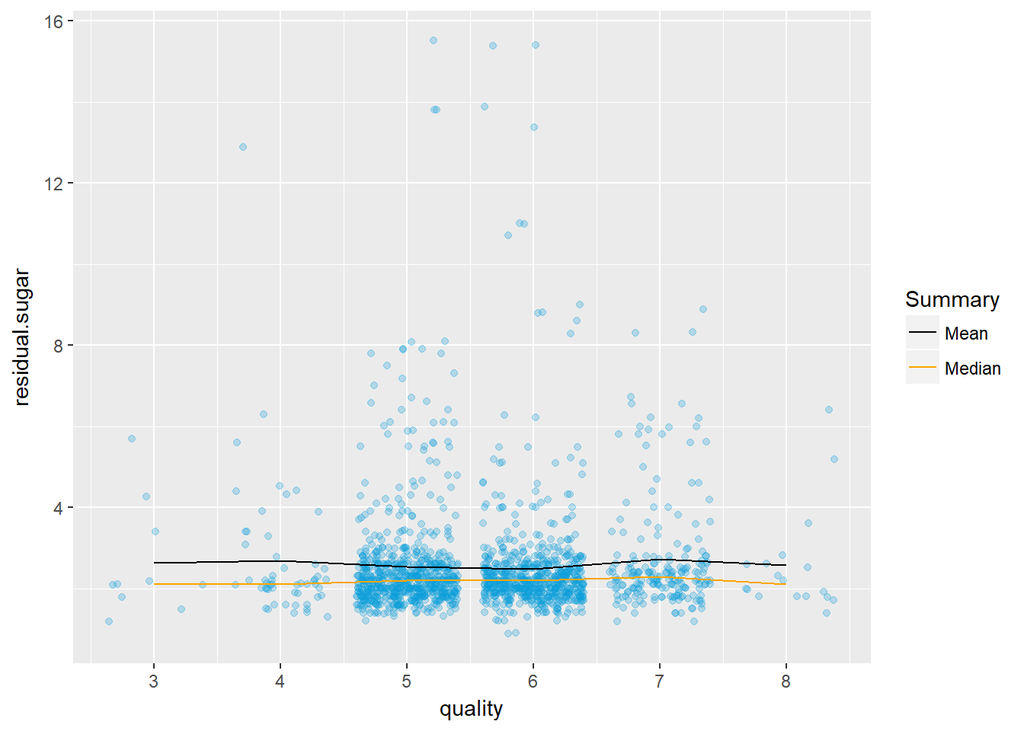

The mean and median values of residual.sugar fluctuate and there is no way we can establish a pattern here. Based on the above plots, residual.sugar seems to have no considerable impact on quality.

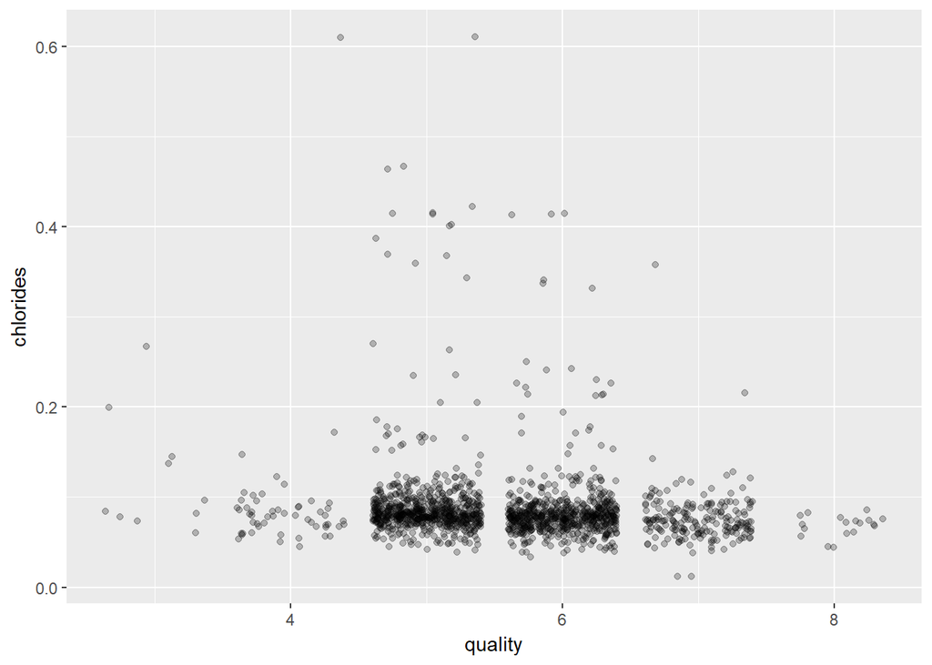